# [İstatistiklerle Kadın, 2020](https://data.tuik.gov.tr/Bulten/Index?p=Istatistiklerle-Kadin-2020-37221&dil=1)

TÜİK

05/03/2021

#### Türkiye nüfusunun %49.87’unu kadınlar, %50.13’ini erkekler oluşturdu

Adrese Dayalı Nüfus Kayıt Sistemi (ADNKS) sonuçlarına göre; 2020 yılında, kadın nüfus 41698377 kişi, erkek nüfus 41915985 kişi oldu. Diğer bir ifadeyle; toplam nüfusun %49.9’unu kadınlar, %50.1’ini ise erkekler oluşturdu. Kadınlar ile erkekler arasındaki bu oransal denge, kadınların daha uzun yaşaması nedeniyle, 60 ve daha yukarı yaş grubundan itibaren kadınların lehine değişti. Kadın nüfusun oranı, 60-74 yaş grubunda %52.3 iken 90 ve üzeri yaş grubunda %73.4 oldu.

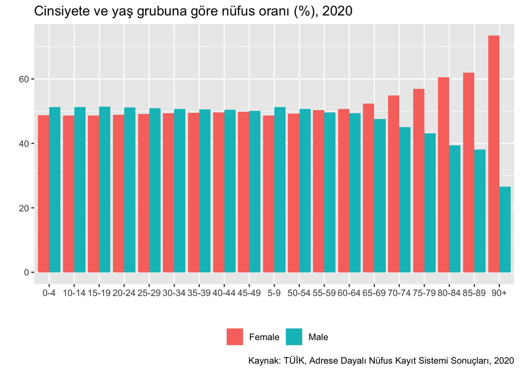

#### Doğuşta beklenen yaşam süresi kadınlarda 81.3 yıl, erkeklerde 75.9 yıl oldu

Hayat tabloları, 2017-2019 sonuçlarına göre; doğuşta beklenen yaşam süresi, Türkiye geneli için toplamda 78.6 yıl, kadınlarda 81.3 yıl, erkeklerde 75.9 yıl oldu. Genel olarak kadınlar erkeklerden daha uzun süre yaşamakta olup doğuşta beklenen yaşam süresi farkı 5.4 yıldır.

#### Ortalama ilk evlenme yaşı kadınlarda 25,1, erkeklerde 27,9 oldu

Evlenme istatistiklerine göre; resmi olarak ilk evliliğini 2020 yılında yapmış olan kadınların ortalama evlenme yaşı 25,1 iken erkeklerin ortalama evlenme yaşı 27,9 oldu. Ortalama ilk evlenme yaşının en yüksek olduğu il, kadınlarda 27,6 yaş, erkeklerde 31,3 yaş ile Tunceli oldu. Ortalama ilk evlenme yaşının en düşük olduğu iller ise kadınlarda 22,2 yaş ile Ağrı, erkeklerde 26,0 yaş ile Şanlıurfa oldu.

En yüksek ve en düşük ortalama ilk evlenme yaşına sahip ilk 3 ilin cinsiyete göre dağılımı, 2020

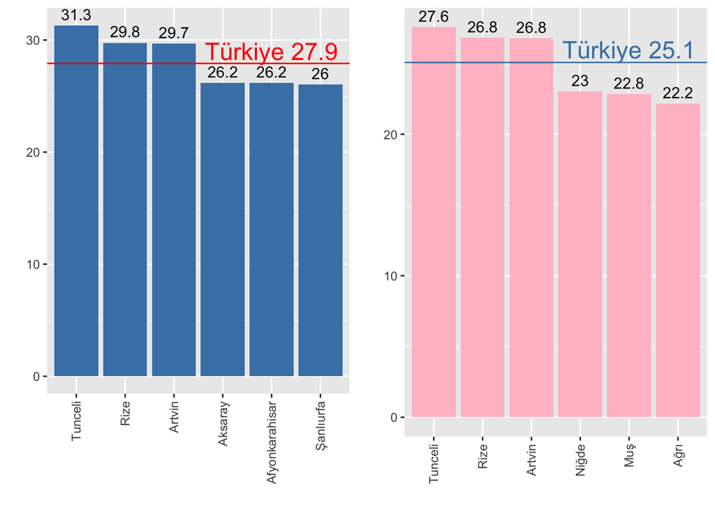